# Analysis of Phage Display Protease and Supernatant Screens

Enoch Yu

2025-08-10

# Introduction

A substrate phage display library of randomized 5-mers was constructed, with each 5-mer having a FLAG peptide at the end. Phages were immobilized onto anti-FLAG beads, and the phage library was screened against 3 neutrophil serine proteases: cathepsin G, elastase, and human proteinase 3 (hPR3). This was followed by 2 controls: with no protease (baseline phage release) and with a FLAG peptide elution (unselected phage library). All were conducted in triplicate.

Screening was repeated for the supernatant releasate of activated neutrophils, in the presence of no inhibitors, AEBSF, EDTA, and AEBSF+EDTA. The broad-spectrum inhibitor AEBSF inhibits serine proteases, while EDTA inhibits metalloproteases. The supernatant formed a complex biological mixture for subsequent analysis.

After incubation, cleaved/released phages are collected, with its DNA isolated and purified, followed by 2 rounds of PCR and high-throughput sequencing on Nextseq2000. Sequencing reads were assembled, quality filtered, and translated into a counts table of cleaved peptides.

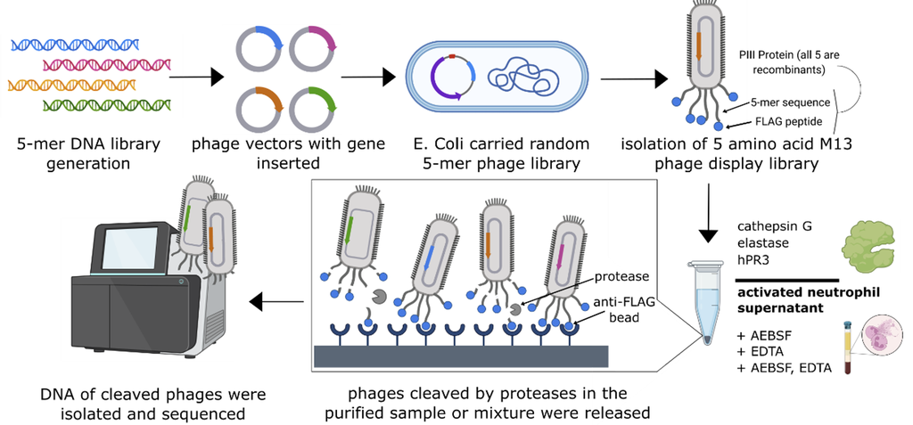

Phage library generation and experimental design

# Setup for Analysis

This R markdown file will conduct the data analysis for the Deep Protease Profiling manuscript, using 2 files as the starting point. These files are the counts of cleaved peptides across proteases and across supernatant mixtures, generated from the GitHub pipeline with a row-sum filter of 6. These files were provided as supplementary data files and can be obtained at our GitHub repository.

neutrophil_mixture_data.csv neutrophil_serine_protease_data.csv

To proceed, please place these 2 files in the same directory as this R markdown file. This R markdown also should be run after a prior R markdown file (CombinedAnalysis.Rmd). 6 control frequency files previously generated would be used in this R markdown file.

### Opening Files

Cleaved peptide counts were passed through a rowsum filter of 6. The unfiltered counts table was presented in the supplementary data files.

```r
set.seed(123)
protease_counts <- read.csv(file = "neutrophil_serine_protease_data.csv", header=TRUE,row.names=1)
mixture_counts <- read.csv(file = "neutrophil_mixture_data.csv", header=TRUE,row.names=1)
```

Data Parameters for the protease conditions were loaded: cathepsin G, elastase, hPR3, no protease (negative control), and FLAG peptide elution of phage (positive control). Each treatment was conducted in triplicate.

```r
proteases = c("cathepsin G","elastase","hPR3","no protease")
protease_replicates = c("C1", "C2", "C3", "E1", "E2", "E3", "H1", "H2", "H3", "V1", "V2", "V3", "N1", "N2", "N3")
protease_col = c("cathepsin G","cathepsin G","cathepsin G" ,"elastase","elastase","elastase","hPR3","hPR3","hPR3","no protease", "no protease", "no protease", "FLAG","FLAG","FLAG")
protease_colname = c("cathepsin G 1","cathepsin G 2","cathepsin G 3","elastase 1","elastase 2","elastase 3","hPR3 1","hPR3 2","hPR3 3","no protease 1", "no protease 2", "no protease 3", "FLAG 1","FLAG 2","FLAG 3")
control = "FLAG"
```

Data Parameters for the mixture conditions were loaded: supernatant mixtures of activated neutrophils with no inhibitor, with AEBSF, with EDTA, with AEBSF + EDTA, and FLAG peptide elution of phage (positive control). Each treatment was conducted in triplicate.

```r
mixtures = c("no inhibitor","AEBSF","EDTA","AEBSF+EDTA")
mixture_replicates = c("NI1","NI2","NI3","A1","A2","A3","ED1","ED2","ED3","AE1","AE2","AE3","G1","G2","G3")
mixture_col = c("no inhibitor","no inhibitor","no inhibitor", "AEBSF","AEBSF","AEBSF","EDTA","EDTA","EDTA","AEBSF+EDTA","AEBSF+EDTA","AEBSF+EDTA","FLAG","FLAG","FLAG")
mixture_colname = c("no inhibitor 1","no inhibitor 2","no inhibitor 3","AEBSF 1","AEBSF 2","AEBSF 3","EDTA 1","EDTA 2","EDTA 3","AEBSF+EDTA 1", "AEBSF+EDTA 2", "AEBSF+EDTA 3", "FLAG 1","FLAG 2","FLAG 3")
```

Necessary packages were loaded: dplyr, tidyr, RColorBrewer, reshape, factoextra, stringr, openxlsx, stats, multcomp, Hmisc, gridExtra, tidyverse, ggplot2, ggseqlogo, ggpubr, ggbeeswarm, ggVennDiagram, ggVenn, pheatmap, PoiClaClu, BiocManager, S4Arrays, DelayedArray, DESeq2, DECIPHER, plotly, plot3D, dbscan, forcats, umap, immunedeconv, plotly, clusterSim

# Initial Analysis of Protease and Mixture Profiles

The cleaved peptides data was analyzed with a bioinformatics approach, adapting computational packages developed for DNA and RNA sequencing datasets.

## DESeq2 Analysis Set Up

DESeq2 was employed for data normalization and differential enrichment analysis to identify peptides significantly cleaved relative to control (the unselected phage library). Prior to analysis, peptides with a stop codon or row sum below 10 were removed.

DESeq2 Analysis on Peptide Dataset for Proteases

```r
data_NS <- subset(protease_counts, grepl("X", row.names(protease_counts))==FALSE)
countData <- as.matrix(data_NS)
colData <- data.frame(condition=factor(protease_col))
dds=DESeqDataSetFromMatrix(countData, colData, formula(~ condition))
```

```
##   Note: levels of factors in the design contain characters other than
##   letters, numbers, '_' and '.'. It is recommended (but not required) to use
##   only letters, numbers, and delimiters '_' or '.', as these are safe characters
##   for column names in R. [This is a message, not a warning or an error]
```

```r
dds$condition <- relevel(dds$condition, ref = "FLAG")
keep <- rowSums(counts(dds)) >= 10
dds_protease <- dds[keep,]
```

DESeq2 Analysis on Peptide Dataset for Mixtures

```r
data_NS <- subset(mixture_counts, grepl("X", row.names(mixture_counts))==FALSE)
countData <- as.matrix(data_NS)
colData <- data.frame(condition=factor(mixture_col))
dds=DESeqDataSetFromMatrix(countData, colData, formula(~ condition))
```

```
##   Note: levels of factors in the design contain characters other than
##   letters, numbers, '_' and '.'. It is recommended (but not required) to use
##   only letters, numbers, and delimiters '_' or '.', as these are safe characters
##   for column names in R. [This is a message, not a warning or an error]
```

```r
dds$condition <- relevel(dds$condition, ref = "FLAG")
keep <- rowSums(counts(dds)) >= 10
dds_mixture <- dds[keep,]
```

DESeq2 Analysis and File Save for Future Testing

```r
dds_protease=DESeq(dds_protease)
dds_mixture=DESeq(dds_mixture)
saveRDS(dds_protease, file = paste0("protease_dds_object.rds"))
saveRDS(dds_mixture, file = paste0("mixture_dds_object.rds"))
```

## Clustering Analysis

Poisson distance hierarchal clustering and PCA (principal component analysis) visualization was conducted on the DESeq2-normalized datasets to assess intra- and inter-condition variability. Clustering also provided an overview of broad-scale substrate cleavage patterns, displaying similarities/differences across conditions.

Poisson Distance Dendrogram for Proteases

```r
colors <- colorRampPalette( rev(brewer.pal(9, "Blues")) )(255)

poisd_protease <- PoissonDistance(t(counts(dds_protease)))
samplePoisDistMatrix <- as.matrix(poisd_protease$dd)
rownames(samplePoisDistMatrix) <- paste(dds_protease$condition)
colnames(samplePoisDistMatrix) <- NULL
rownames(samplePoisDistMatrix) <- paste(protease_colname)
pheatmap(samplePoisDistMatrix, clustering_distance_rows = poisd_protease$dd, clustering_distance_cols = poisd_protease$dd, col = colors)
```

Poisson Distance Dendrogram for Mixtures

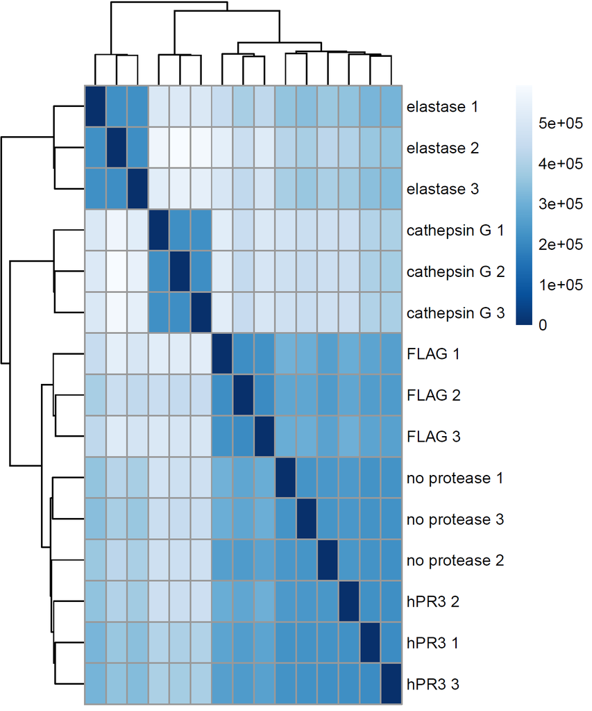

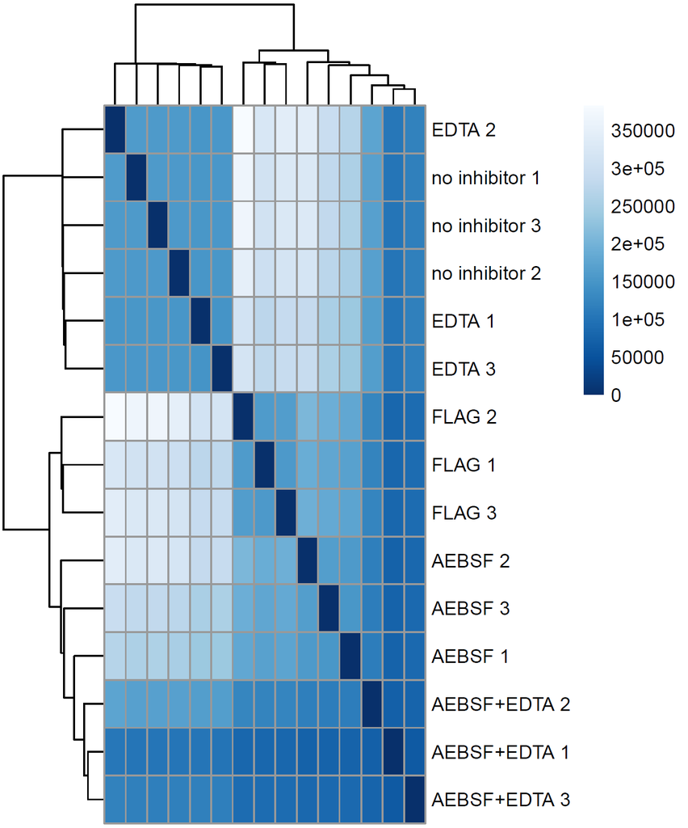

Poisson Distance Plots for Proteases (Left) and Mixtures (Right)

```r
poisd_mixture <- PoissonDistance(t(counts(dds_mixture)))
samplePoisDistMatrix <- as.matrix(poisd_mixture$dd)
rownames(samplePoisDistMatrix) <- paste(dds_mixture$condition)
colnames(samplePoisDistMatrix) <- NULL
rownames(samplePoisDistMatrix) <- paste(mixture_colname)
pheatmap(samplePoisDistMatrix, clustering_distance_rows = poisd_mixture$dd, clustering_distance_cols = poisd_mixture$dd, col = colors)
```

PCA Plots for Protease and Mixture conditions

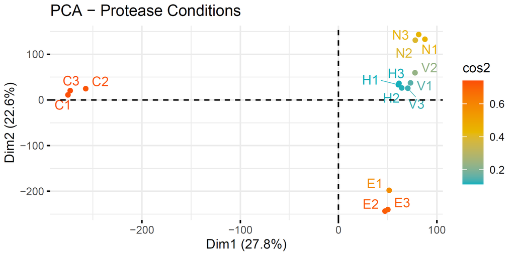

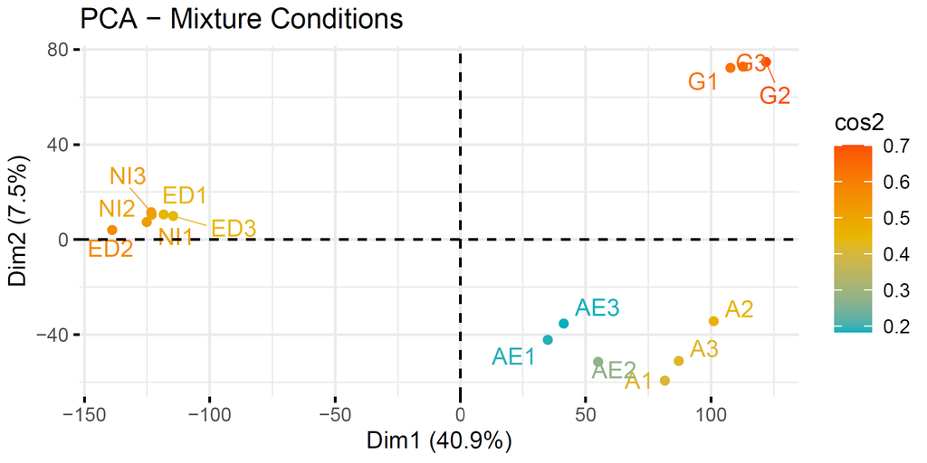

PCA Plots for Proteases (Left) and Mixtures (Right)

```r
rld <- rlog(dds_protease, blind=FALSE)
pca <- prcomp(t(assay(rld)))
fviz_pca_ind(pca, col.ind = "cos2", gradient.cols = c("#00AFBB", "#E7B800", "#FC4E07"), repel = TRUE, title = "PCA - Protease Conditions")

rld <- rlog(dds_mixture, blind=FALSE)
pca <- prcomp(t(assay(rld)))
fviz_pca_ind(pca, col.ind = "cos2", gradient.cols = c("#00AFBB", "#E7B800", "#FC4E07"), repel = TRUE, title = "PCA - Mixture Conditions")
```

# Generation of Significantly Cleaved Peptides

Phage libraries are known to possess baseline compositional bias in amino acid expression, impacting peptides and sequence counts. To account for background bias, DESeq2 identified peptides significantly enriched against the unselected library as control (FLAG peptide elution). These cleaved peptides were used to capture a proteolytic activity profile for that protease or mixture.

To limit false positives, a Bonferroni correction with stringent thresholds of an adjusted p-value < 10^-9 and log 2-fold change > 1 were applied. Peptides that met these conditions were classified as a significantly cleaved peptide.

Defining Parameters and Thresholds

```r
pvalthreshold = 0.000000001
log2foldthreshold = 1
combined <- append(proteases, mixtures)
peptideList <- list()
```

Differential Enrichment Analysis for Protease Conditions

```r
for(i in 1:length(proteases)){
  res_bonf <- results(dds_protease, contrast=c("condition",proteases[i],"FLAG"), alpha=pvalthreshold,pAdjustMethod = "bonf")
  res_bonf_sig <- subset(as.data.frame(res_bonf[order(res_bonf$pvalue),]), padj < pvalthreshold)
  AA_seq <- rownames(res_bonf_sig)
  res_bonf_sig  <- cbind(AA_seq, res_bonf_sig)
  res_bonf_sig_enrich <- subset(as.data.frame(res_bonf_sig[order(res_bonf$baseMean),]), log2FoldChange > log2foldthreshold)
  bonf_sig_AA <- as.character(rownames(res_bonf_sig_enrich))
  print(paste0(proteases[i], ": ", length(res_bonf_sig_enrich$baseMean)))
  write.table(res_bonf_sig_enrich,file=paste0("deseq2_", proteases[i],".txt"), col.names=TRUE, append=FALSE, quote=FALSE, row.names = FALSE)
  write.table(bonf_sig_AA,file=paste0("sig_peptides_", proteases[i],".txt"), col.names=FALSE, append=FALSE, quote=FALSE, row.names = FALSE)
  peptideList <- append(peptideList, list(bonf_sig_AA))
  names(peptideList)[length(peptideList)] <- proteases[i]
}
```

```
## [1] "cathepsin G: 5985"
## [1] "elastase: 5325"
## [1] "hPR3: 1285"
## [1] "no protease: 1291"
```

Differential Enrichment Analysis for Mixture Conditions

```r
for(i in 1:length(mixtures)){
  res_bonf <- results(dds_mixture, contrast=c("condition",mixtures[i],"FLAG"), alpha=pvalthreshold,pAdjustMethod = "bonf")
  res_bonf_sig <- subset(as.data.frame(res_bonf[order(res_bonf$pvalue),]), padj < pvalthreshold)
  AA_seq <- rownames(res_bonf_sig)
  res_bonf_sig  <- cbind(AA_seq, res_bonf_sig)
  res_bonf_sig_enrich <- subset(as.data.frame(res_bonf_sig[order(res_bonf$baseMean),]), log2FoldChange > log2foldthreshold)
  bonf_sig_AA <- as.character(rownames(res_bonf_sig_enrich))
  print(paste0(mixtures[i], ": ", length(res_bonf_sig_enrich$baseMean)))
  write.table(res_bonf_sig_enrich,file=paste0("deseq2_", mixtures[i],".txt"), col.names=TRUE, append=FALSE, quote=FALSE, row.names = FALSE)
  write.table(bonf_sig_AA,file=paste0("sig_peptides_", mixtures[i],".txt"), col.names=FALSE, append=FALSE, quote=FALSE, row.names = FALSE)
  peptideList <- append(peptideList, list(bonf_sig_AA))
  names(peptideList)[length(peptideList)] <- mixtures[i]
}
```

```
## [1] "no inhibitor: 5166"
## [1] "AEBSF: 558"
## [1] "EDTA: 5190"
## [1] "AEBSF+EDTA: 313"
```

MA plots

To visualize the peptides and their corresponding counts or log 2 fold change, relative to control, MA plots were made. Blue dots represent peptides with a Bonferroni p-adj < 10^-9.

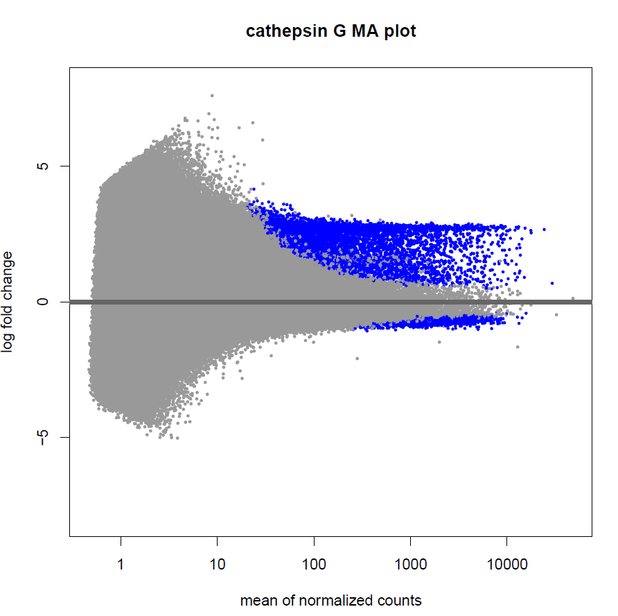

Example of a MA plot for cathepsin G

```r
for (i in 1:length(proteases)){
  res_bonf <- results(dds_protease, contrast=c("condition",proteases[i],control), alpha=pvalthreshold,pAdjustMethod = "bonferroni")
  pdf(paste0(proteases[i], '_DEseq_plotMA.pdf'))
  plotMA(res_bonf,alpha=pvalthreshold,ylim=c(-8,8),main='Plot')
  dev.off()
}
for (i in 1:length(mixtures)){
  res_bonf <- results(dds_mixture, contrast=c("condition",mixtures[i],control), alpha=pvalthreshold,pAdjustMethod = "bonferroni")
  pdf(paste0(mixtures[i], '_DEseq_plotMA.pdf'))
  plotMA(res_bonf,alpha=pvalthreshold,ylim=c(-8,8),main='Plot')
  dev.off()
}
```

Sequence Logos

For the significantly cleaved peptides, sequence logos were constructed using ggseqlogo to depict amino acid motifs.

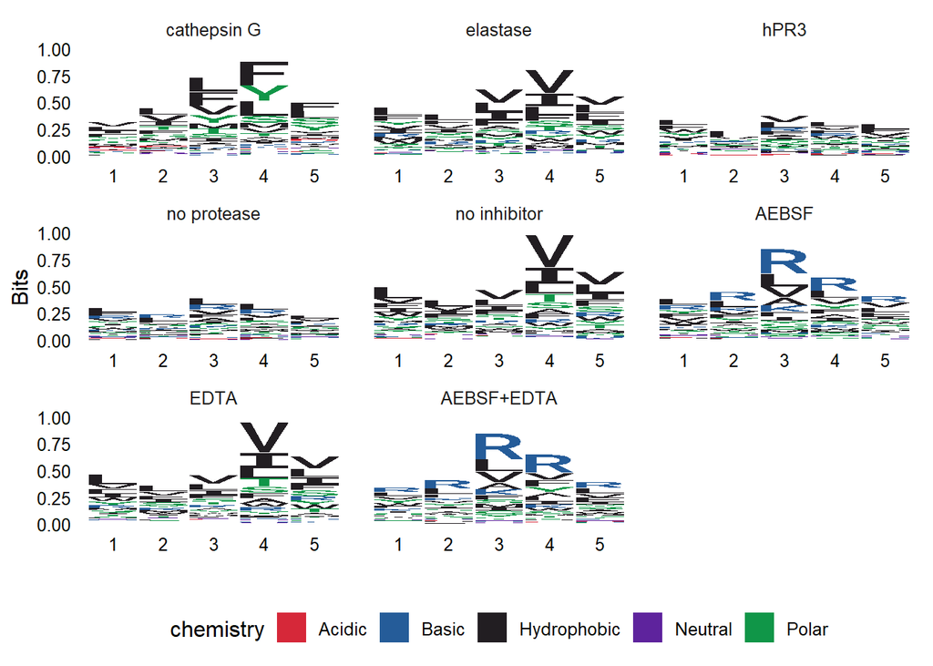

```r
proteases_list <- list(`cathepsin G` = peptideList$`cathepsin G`,elastase=peptideList$elastase, hPR3=peptideList$hPR3, `no protease`=peptideList$`no protease`)
mixtures_list <- list(`no inhibitor` = peptideList$`no inhibitor`,AEBSF=peptideList$AEBSF, EDTA=peptideList$EDTA, `AEBSF+EDTA`=peptideList$`AEBSF+EDTA`)
combined_list <- append(proteases_list, mixtures_list)
ggseqlogo(combined_list)
```

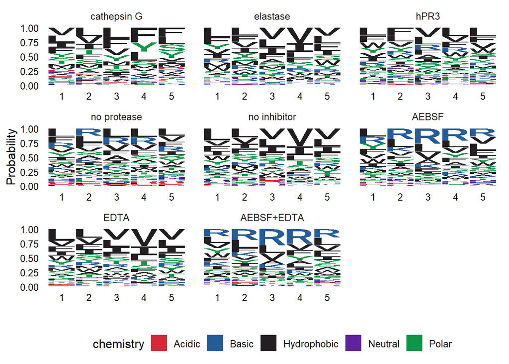

```r
ggseqlogo(combined_list, method = 'prob')
```

## Peptide Space Comparisons

Venn diagrams using ggVennDiagram were used to determine the overlap in cleaved peptides between proteases, mixtures, and other conditions, as well as areas of distinct activity.

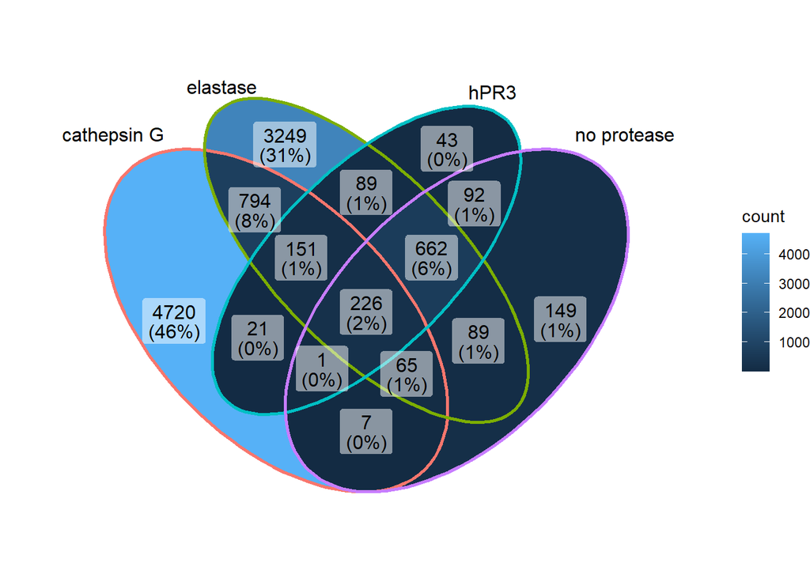

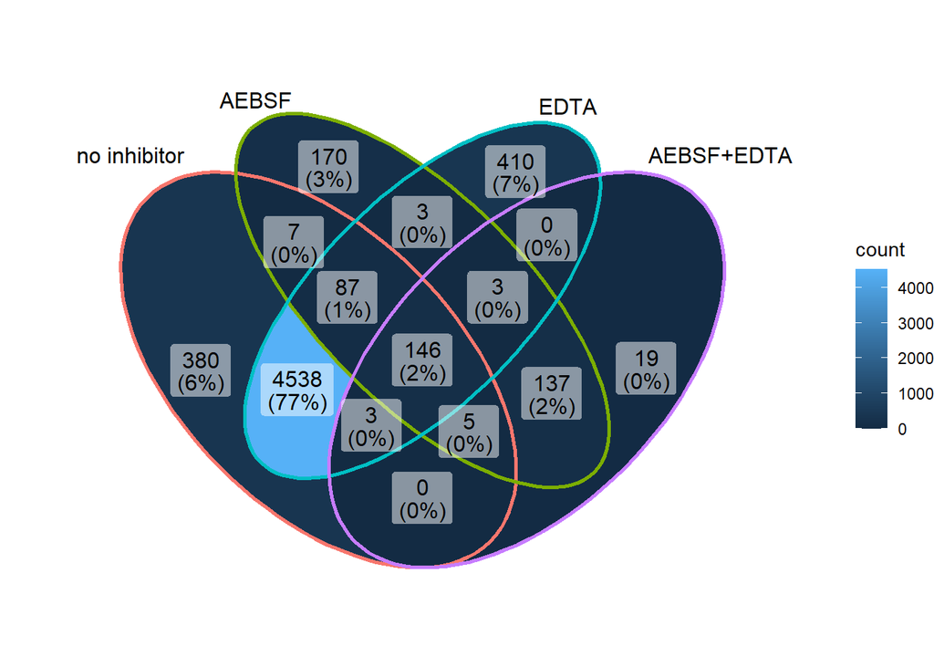

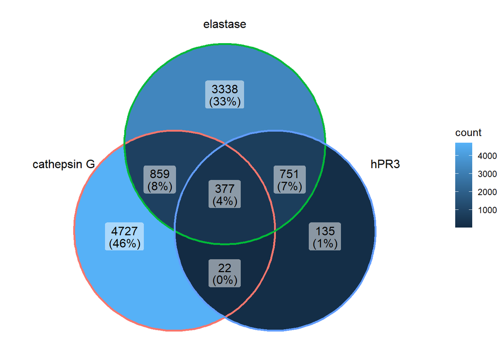

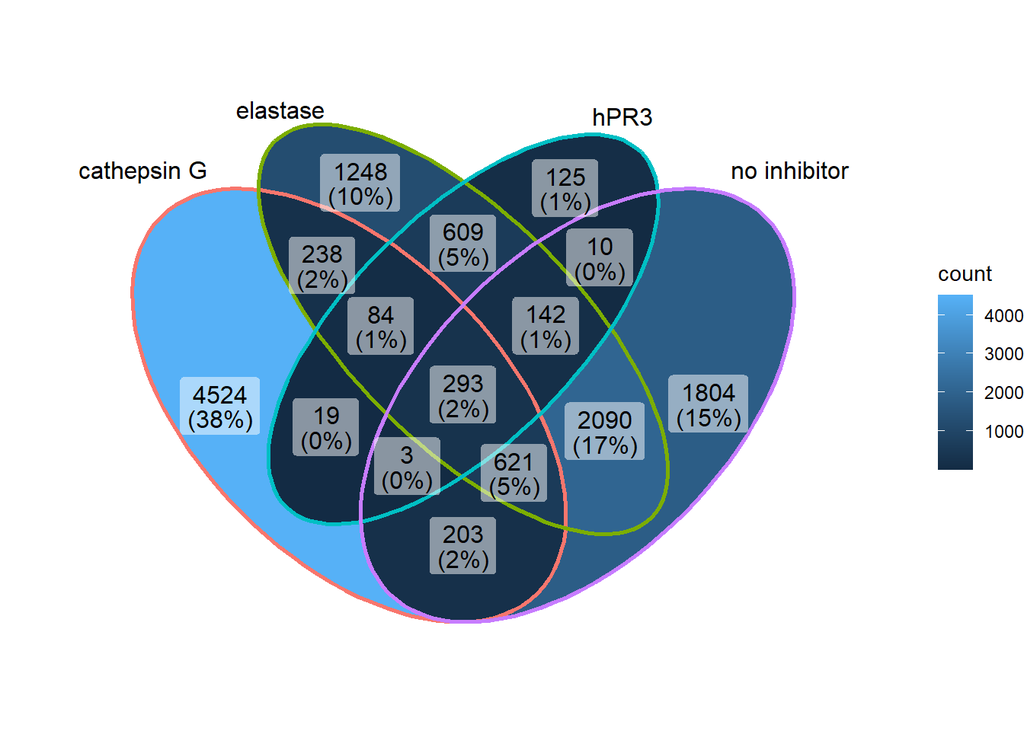

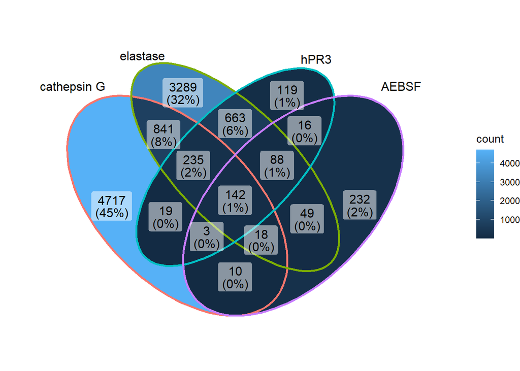

Functions to Convert Peptides between TXT and Fasta files

```r
txt_to_fasta <- function(fname) {
  AA_seqs <- scan(file=paste0(fname, ".txt"), what="", sep="\n")
  fastaFile <- paste0(fname,".fasta")
  fileConn<-file(fastaFile)
  sink(fastaFile)
  AA_seqs <- as.data.frame(AA_seqs)
  for (i in 1:length(AA_seqs$AA_seqs)){
    cat(paste0(">",AA_seqs$AA_seqs[i]))
    cat("\n")
    cat(AA_seqs$AA_seqs[i])
    cat("\n")
  }
  close(fileConn)
  sink()
}

fasta_to_txt <- function(fname) {
  AA_seqs <- scan(file=paste0(fname, ".fasta"), what="", sep="\n")
  AA_seqs <- AA_seqs[!grepl(">", AA_seqs)]
  txtFile <- paste0(fname,".txt")
  fileConn<-file(txtFile)
  sink(txtFile)
  AA_seqs <- as.data.frame(AA_seqs)
  for (i in 1:length(AA_seqs$AA_seqs)){
    cat(AA_seqs$AA_seqs[i])
    cat("\n")
  }
  close(fileConn)
  sink()
}
```

## Unsupervised Alignment of Significantly Cleaved Peptides, using Decipher

In this 5-mer peptide format, a key limitation was that proteolytic cleavage may have occurred anywhere along the 5-mer. Based on 4 possible P1-P1’ cleavage sites, this formed a 9-mer alignment space. The DECIPHER R Package was used to perform unsupervised alignment and estimate the P1 position.

This alignment was conducted on the significantly cleaved peptides previously determined for each condition. The parameter terminalGap was adjusted to fit peptides into 9-mer space.

```r
for(i in 1:length(combined)){
  txt_to_fasta(paste0("sig_peptides_",combined[i]))
  fastaFile <- paste0("sig_peptides_",combined[i], ".fasta")
  seqs <- readAAStringSet(fastaFile)
  aligned <- AlignSeqs(seqs, gapOpening = -200, useStructures = TRUE, terminalGap = -8)
  #the parameter terminalGap was adjusted to fit 9-mer space
  writeXStringSet(aligned,file= paste0("aligned_sig_peptides_",combined[i], ".fasta"))
  fasta_to_txt(paste0("aligned_sig_peptides_",combined[i]))
}
```

Sequence Logos of Aligned Peptides

The aligned position with the most dominant motifs was determined as P1 for the 9-mer sequence.

```r
alignedpeptideList <- list()
for(i in 1:length(combined)){
  alignedAA <- read.table(paste0("aligned_sig_peptides_",combined[i], ".txt"))
  df_aligned <- apply(alignedAA, 1, function(row) {
    unlist(strsplit(row, ""))
  })
  df_aligned <- as.data.frame(t(df_aligned))

  seqs <- readAAStringSet(paste0("aligned_sig_peptides_",combined[i], ".fasta"))
  consensus <- consensusMatrix(seqs, as.prob = T)
  consensus <- consensus[rownames(consensus) != "-", ]
  highest_col <- which.max(colSums(consensus * (consensus > 0.095)))
  df_9mer <- df_aligned[, (highest_col-4):(highest_col+4)]
  merged_9mer <- apply(df_9mer, 1, function(row) paste(row, collapse = ""))
  alignedpeptideList <- append(alignedpeptideList, list(merged_9mer))
  names(alignedpeptideList)[length(alignedpeptideList)] <- combined[i]
  write.table(merged_9mer, file = paste0("aligned_9mer_",combined[i], ".txt"), quote = FALSE, row.names = FALSE, col.names = FALSE)
  txt_to_fasta(paste0("aligned_9mer_",combined[i]))
}
```

Logos of aligned peptides were graphed using ggseqlogo.

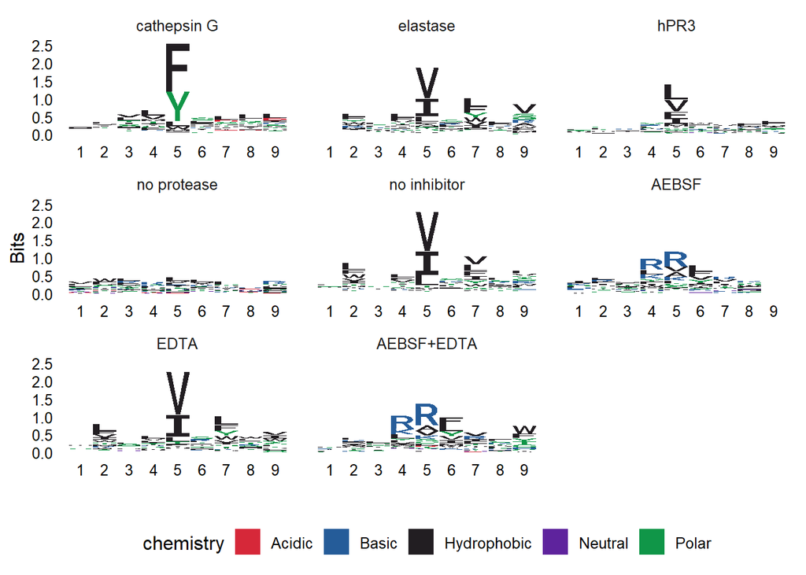

```r
proteases_aligned_list <- list(`cathepsin G` = alignedpeptideList$`cathepsin G`,elastase=alignedpeptideList$elastase, hPR3=alignedpeptideList$hPR3, `no protease`=alignedpeptideList$`no protease`)
mixtures_aligned_list <- list(`no inhibitor` = alignedpeptideList$`no inhibitor`,AEBSF=alignedpeptideList$AEBSF, EDTA=alignedpeptideList$EDTA, `AEBSF+EDTA`=alignedpeptideList$`AEBSF+EDTA`)
combined_aligned_list <- append(proteases_aligned_list, mixtures_aligned_list)
ggseqlogo(combined_aligned_list)
```

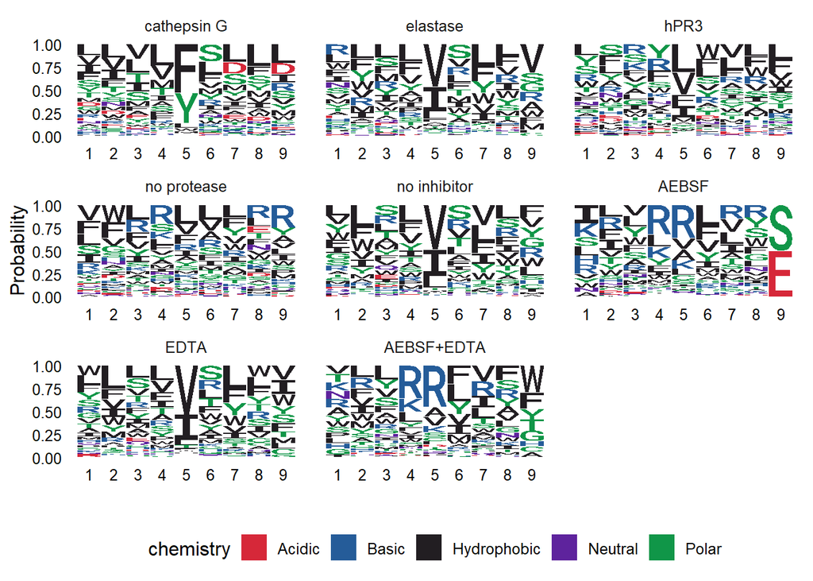

```r
ggseqlogo(combined_aligned_list, method = 'prob')
```

Sequence logos were compared between conditions using Difflogo.

```r
ASN = DiffLogo::Alphabet( #Amino Acid Colors
  c("A","C","D","E","F","G","H","I","K","L","M","N","P","Q","R","S","T","V","W","Y"),
  c('#2E2E2E', '#058644', '#C5003E', '#C5003E','#2E2E2E','#058644', '#0046C5','#2E2E2E', '#0046C5','#2E2E2E','#2E2E2E', '#720091','#2E2E2E','#720091','#0046C5','#058644','#058644', '#2E2E2E', '#2E2E2E','#058644'),
  FALSE
)
AA = c("A", "C", "D", "E", "F", "G", "H", "I", "K", "L", "M", "N", "P", "Q", "R", "S", "T", "V", "W", "Y")

PPMs_list <- list()
aligned_PPMs_list <- list()

for (i in 1:length(combined)){
  sequences = peptideList[[i]]
  AA_counts <- as.data.frame(matrix(nrow=nchar(length(sequences[1])), ncol=20))
  colnames(AA_counts)<-AA
  for (j in 1:nchar(sequences[i])) {
    temp <- substr(sequences, j, j)
    peptideNames <- AA %>%  unique() %>%data.frame(stringsAsFactors = F)
    colnames(peptideNames) <- "peptideNames"
    result<-apply(peptideNames,1,function(x) str_count(temp, x["peptideNames"]))
    colnames(result) <- peptideNames$peptideNames
    result<-result[, AA]
    for (k in 1:20) {
      AA_counts[j,k] <- sum(result[,k])
    }
  }
  AA_counts$total <- apply(AA_counts, 1, sum)
  PPM <- AA_counts/AA_counts$total #position probability matrix
  PPM <- PPM[,1:20]
  PPM <- PPM %>% t() %>% as.data.frame()
  colnames(PPM) <- as.character(1:nchar(sequences[1]))

  PPMs_list[[names(peptideList)[i]]] <- PPM

  sequences = alignedpeptideList[[i]]
  AA_counts <- as.data.frame(matrix(nrow=nchar(length(sequences[1])), ncol=20))
  colnames(AA_counts)<-AA
  for (j in 1:nchar(sequences[i])) {
    temp <- substr(sequences, j, j)
    peptideNames <- AA %>%  unique() %>%data.frame(stringsAsFactors = F)
    colnames(peptideNames) <- "peptideNames"
    result<-apply(peptideNames,1,function(x) str_count(temp, x["peptideNames"]))
    colnames(result) <- peptideNames$peptideNames
    result<-result[, AA]
    for (k in 1:20) {
      AA_counts[j,k] <- sum(result[,k])
    }
  }
  AA_counts$total <- apply(AA_counts, 1, sum)
  PPM <- AA_counts/AA_counts$total #position probability matrix
  PPM <- PPM[,1:20]
  PPM <- PPM %>% t() %>% as.data.frame()
  colnames(PPM) <- as.character(1:nchar(sequences[1]))

  aligned_PPMs_list[[names(alignedpeptideList)[i]]] <- PPM
}
```

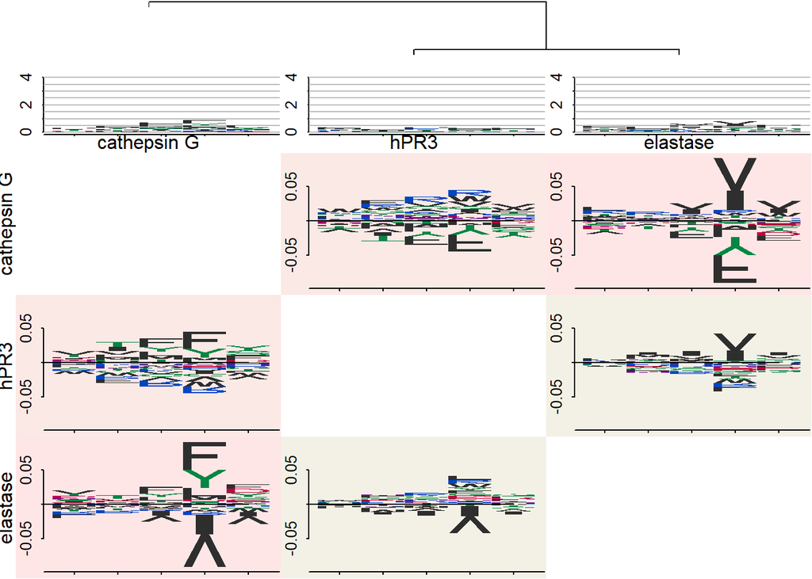

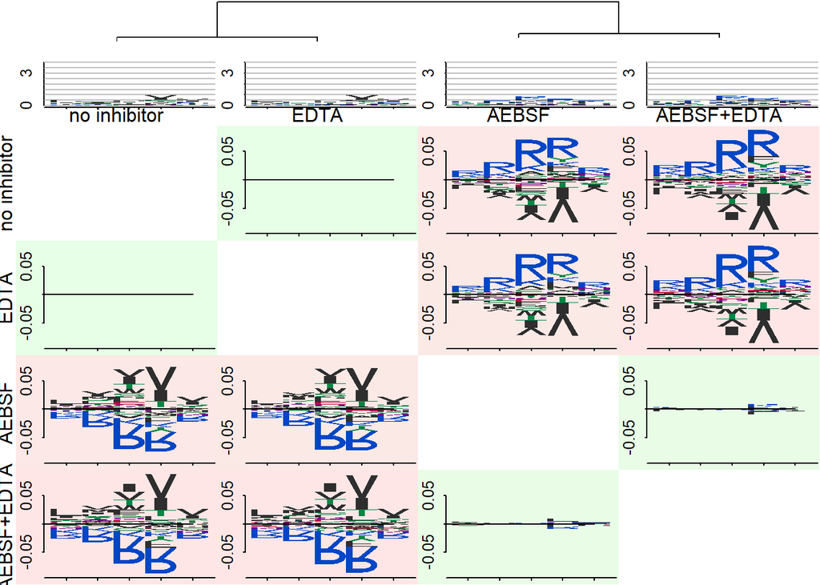

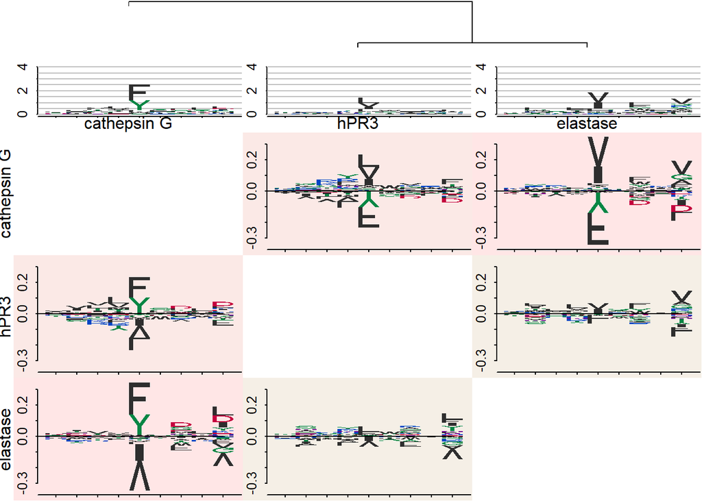

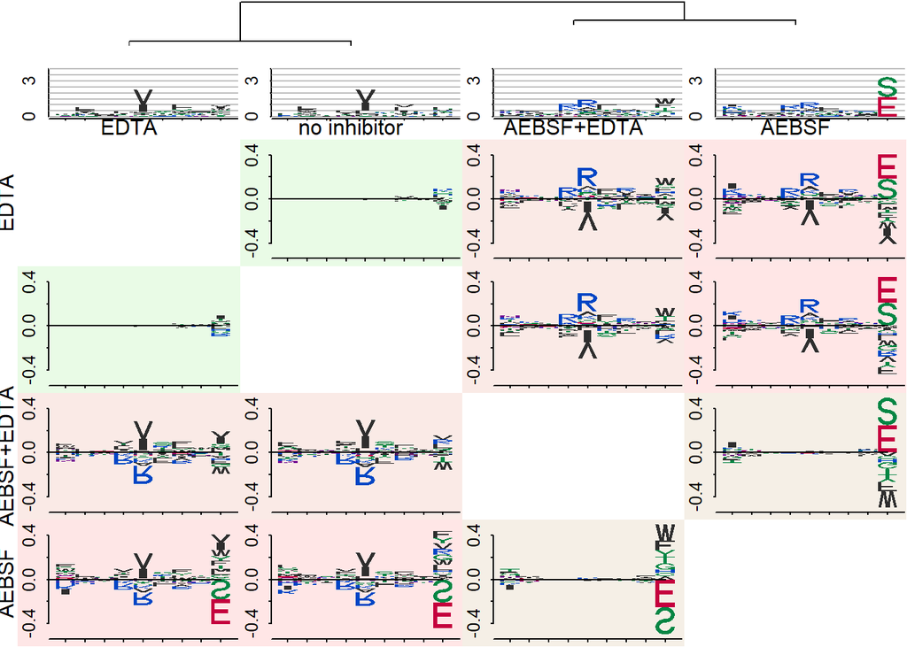

## Synthetic Alignment of Significantly Cleaved Peptides

An alternative supervised alignment method was synthetic alignment, centering peptides at the P1 position based on each protease’s known P1 site preferences. This was conducted for the 3 neutrophil serine proteases. Peptides without the specified amino acids were unaligned.

Cathepsin G: F/Y Elastase: V/I hPR3: V/I

```r
strfind <- function(s, char) { #function for finding the first index where an amino acid appears in the peptide
  temp <- 1
  if(length(rev(grep(char, unlist(strsplit(s, NULL)), fixed=T))) > 1){
    temp <- length(rev(grep(char, unlist(strsplit(s, NULL)), fixed=T)))}
  rev(grep(char, unlist(strsplit(s, NULL)), fixed=T))[temp]}
```

Synthetic Alignment

```r
centers <- list(c("F", "Y"), c("V", "I"), c("V", "I"))
syntheticList <- list()
unalignedList <- list()
for(i in 1:3){
  sequences <- peptideList[[i]]
  synthetic <- c()
  unaligned <- c()
  for(j in 1:length(sequences)){
    pep = sequences[j]
    for(k in 1:length(centers)){
      index <- strfind(pep, centers[[i]][k])
      if(!is.na(index)){break}}
    if(is.na(index)){unaligned <- c(unaligned, pep)
    next}
    left <- 9 - nchar(pep) - index + 1
    right <- index - 1
    alignedpep <- paste0(paste0(rep('-', left), collapse = ""), pep, paste0(rep('-', right), collapse = ""))
    synthetic <- c(synthetic, alignedpep)}
  syntheticList <- append(syntheticList, list(synthetic))
  names(syntheticList)[length(syntheticList)] <- combined[i]
  unalignedList <- append(unalignedList, list(unaligned))
  names(unalignedList)[length(unalignedList)] <- combined[i]
  write.table(synthetic, file = paste0("synthetic_9mer_",combined[i], ".txt"), quote = FALSE, row.names = FALSE, col.names = FALSE)
  txt_to_fasta(paste0("synthetic_9mer_",combined[i]))
}
```

Sequence logos of Synthetically Aligned Peptides

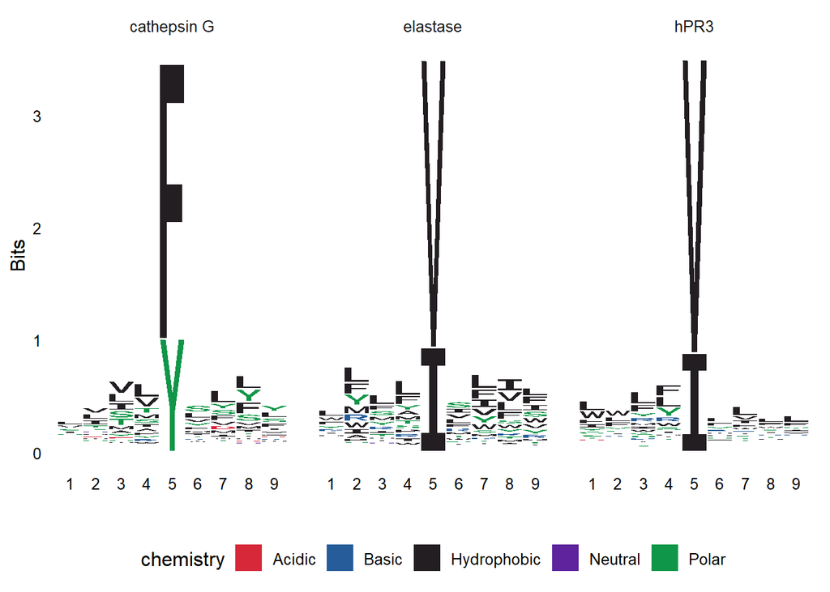

```r
synthetic_aligned_list <- list(`cathepsin G` = syntheticList$`cathepsin G`,elastase=syntheticList$elastase, hPR3=syntheticList$hPR3)
synthetic_unaligned_list <- list(`cathepsin G` = unalignedList$`cathepsin G`,elastase=unalignedList$elastase, hPR3=unalignedList$hPR3)

ggseqlogo(synthetic_aligned_list) #aligned peptides
```

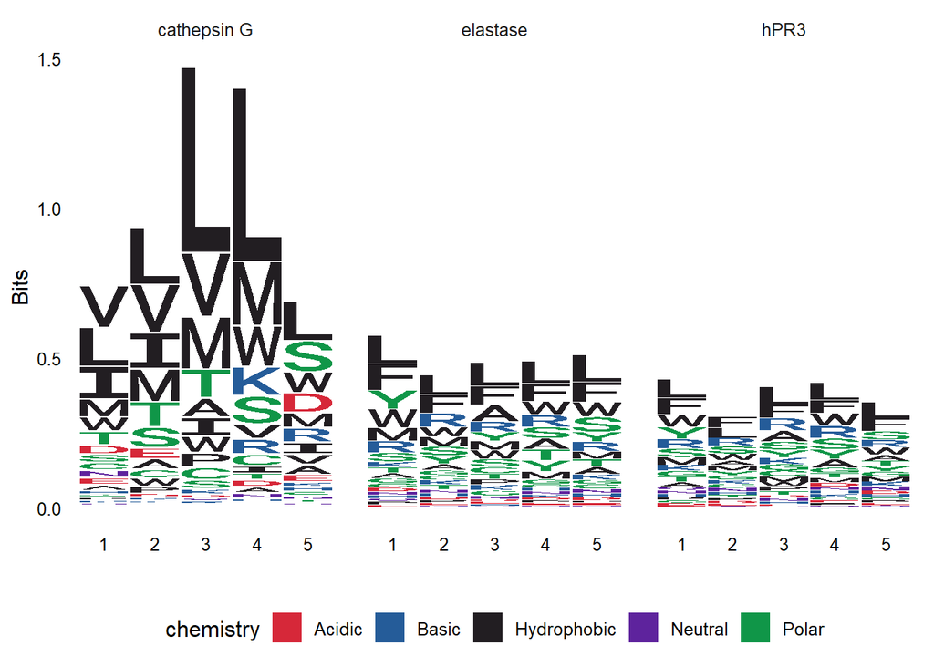

```r
ggseqlogo(synthetic_unaligned_list) #unaligned peptides
```

## Icelogos for Peptides with Unsupervised Alignment, referencing the background unselected library

To assess the relative enrichment of peptides at each position, compared to the background phage library, Icelogos were further generated using the Icelogo SOAP server. Motifs with a p<0.05 for % difference, relative to control

https://github.com/compomics/icelogo

Positive Set: significantly cleaved peptides with DECIPHER alignment Negative Set: list of peptides representing amino acid frequencies of the unselected phage library (FLAG peptide elution)

5-mers Space: (Icelogos for unaligned peptides)

Control Frequencies for Protease Screen: ‘control_frequency_protease.fasta’

Control Frequencies for Mixture Screen: ‘control_frequency_mixture.fasta’

Control Frequencies across both Screens: ‘control_frequency_combined.fasta’

9-mers Space: (Icelogos for aligned peptides)

Control Frequencies for Protease Screen: ‘control_frequency_protease_9mer.fasta’

Control Frequencies for Mixture Screen: ‘control_frequency_mixture_9mer.fasta’

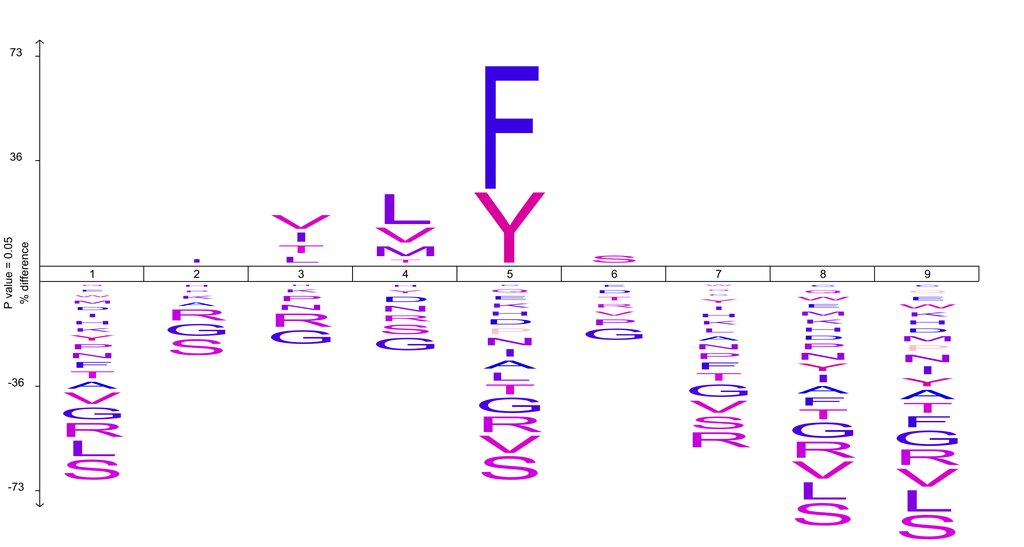

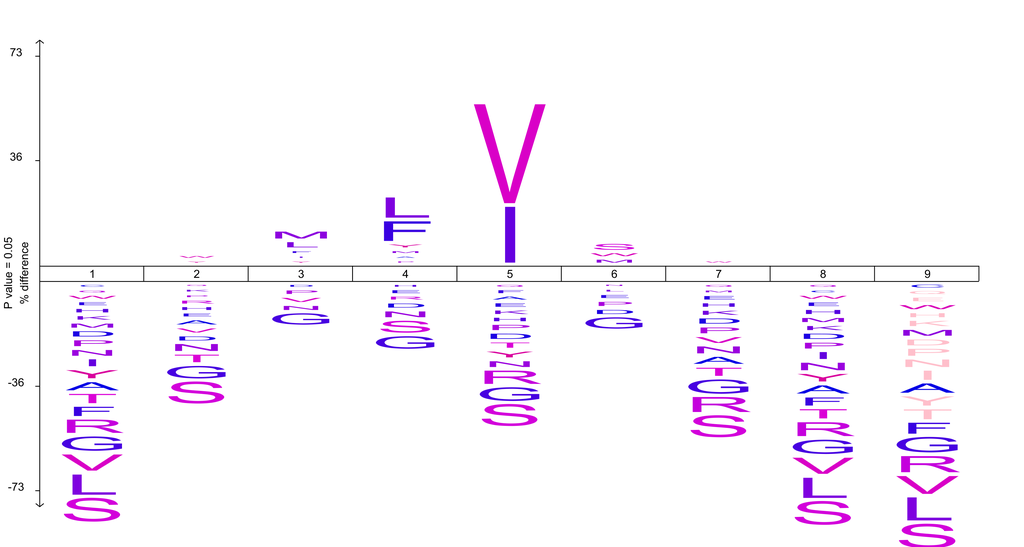

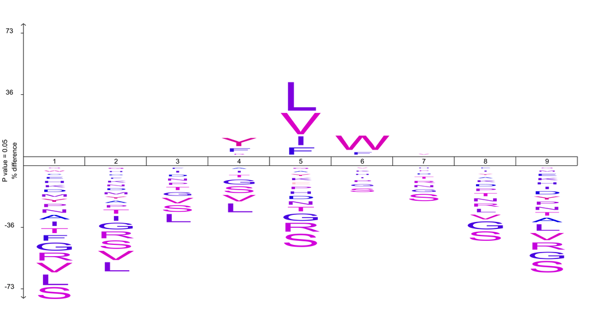

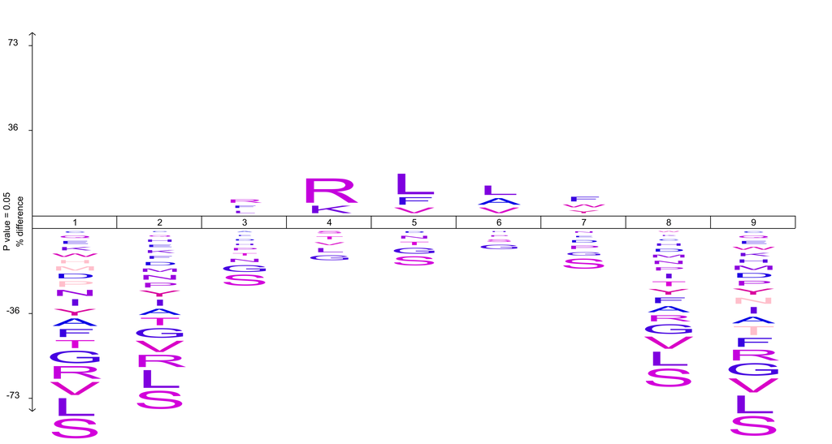

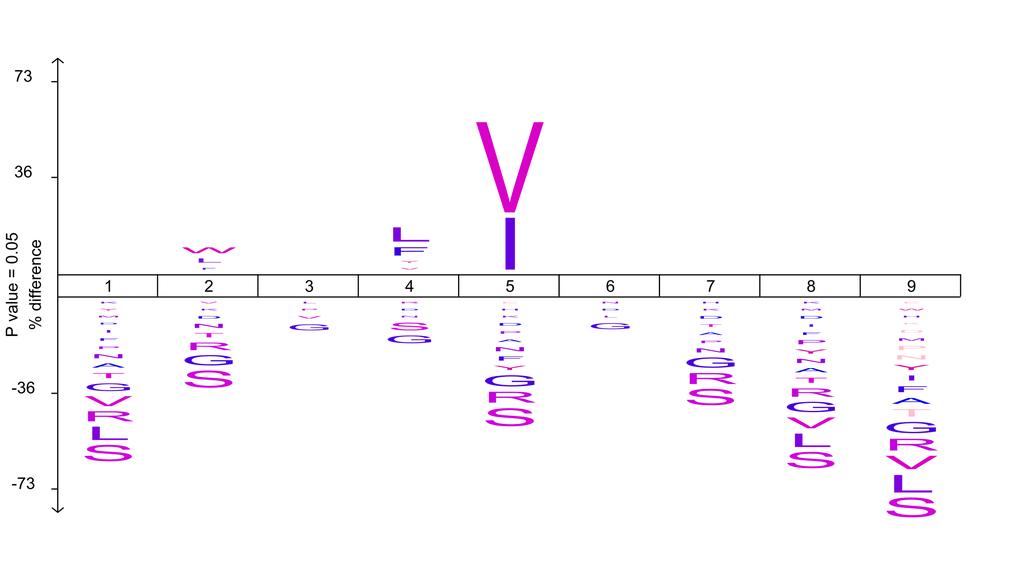

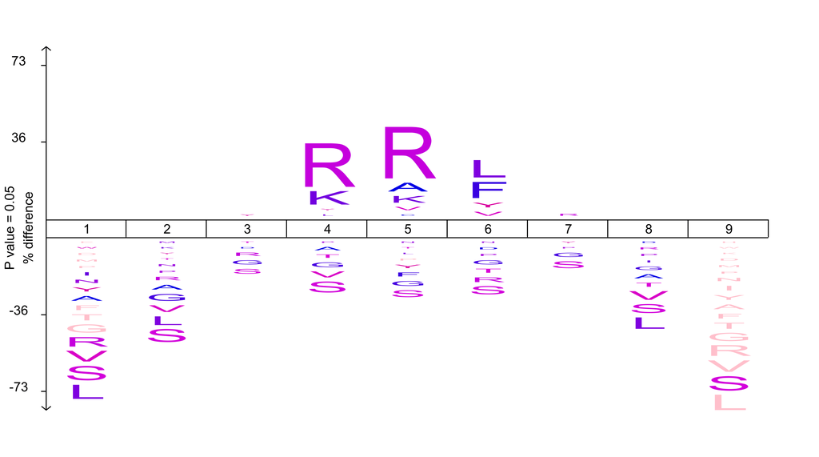

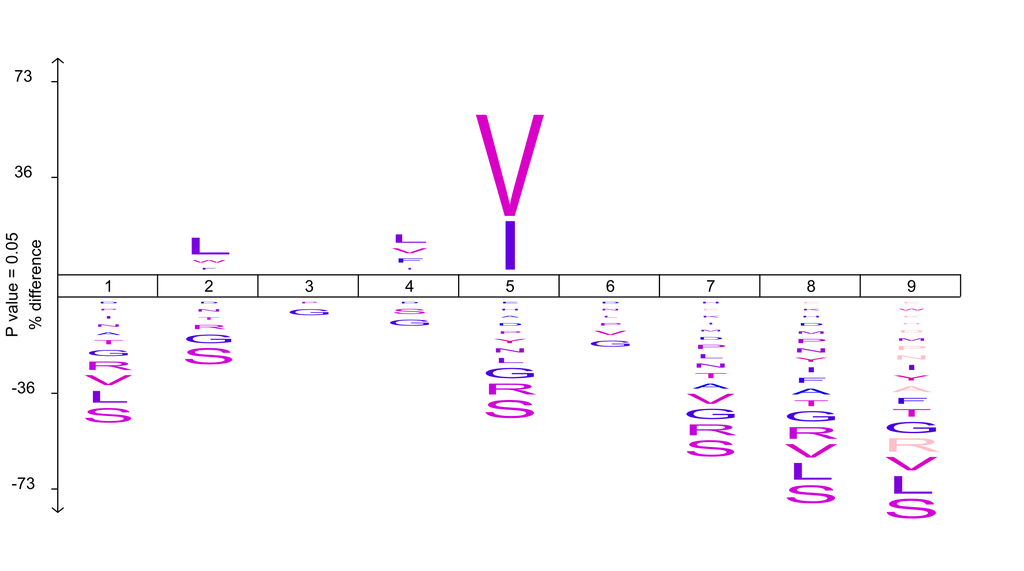

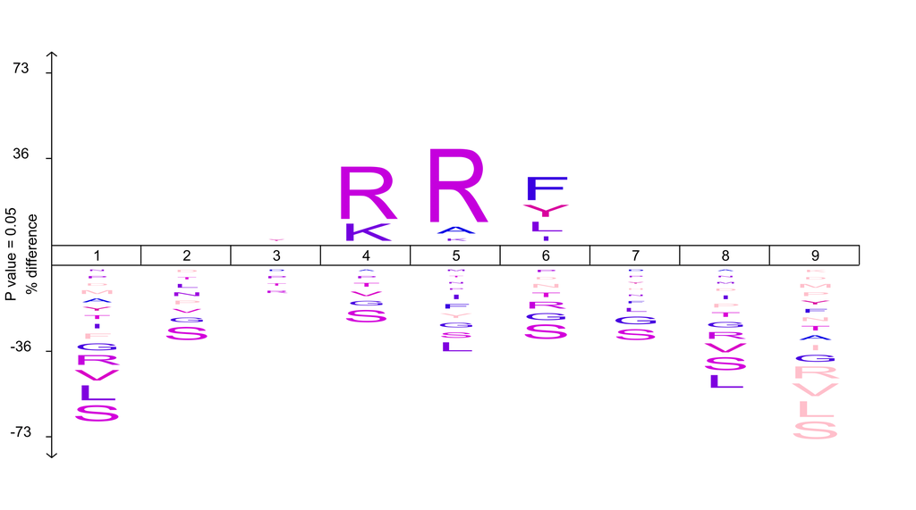

## Icelogos for Peptides with Synthetic Alignment

For 3 proteases with synthetic alignment, to assess if the screen provided a true signal, a similarly synthetically aligned background dataset was used. Every possible peptide from the unselected phage library was synthetically aligned based on F/Y or V/I. This dataset was used as the Negative Set for Icelogo.

```r
data_NS <- subset(protease_counts, grepl("X", row.names(protease_counts))==FALSE)
rowsum_filter <- data_NS[rowSums(data_NS) >= 10, ]
FLAG_peptides <- rownames(rowsum_filter[rowSums(rowsum_filter[, 13:15]) > 0, ])
sequences <- FLAG_peptides

centers <- list(c("F", "Y"), c("V", "I"))
syntheticFLAG <- list()
unalignedFLAG <- list()
for(i in 1:2){
  synthetic <- c()
  unaligned <- c()
  for(j in 1:length(sequences)){
    pep = sequences[j]
    for(k in 1:length(centers)){
      index <- strfind(pep, centers[[i]][k])
      if(!is.na(index)){break}}
    if(is.na(index)){unaligned <- c(unaligned, pep)
    next}
    left <- 9 - nchar(pep) - index + 1
    right <- index - 1
    alignedpep <- paste0(paste0(rep('-', left), collapse = ""), pep, paste0(rep('-', right), collapse = ""))
    synthetic <- c(synthetic, alignedpep)}
  syntheticFLAG <- append(syntheticFLAG, list(synthetic))
  names(syntheticFLAG)[length(syntheticFLAG)] <- i
  unalignedFLAG <- append(unalignedFLAG, list(unaligned))
  names(unalignedFLAG)[length(unalignedFLAG)] <- i
  write.table(synthetic, file = paste0("synthetic_9mer_FLAG", i, ".txt"), quote = FALSE, row.names = FALSE, col.names = FALSE)
  txt_to_fasta(paste0("synthetic_9mer_FLAG", i,combined[i]))
  write.table(unaligned, file = paste0("unaligned_synthetic_9mer_FLAG", i, ".txt"), quote = FALSE, row.names = FALSE, col.names = FALSE)
  txt_to_fasta(paste0("unaligned_synthetic_9mer_FLAG", i,combined[i]))
}

for(i in 1:2){
  write.table(synthetic, file = paste0("synthetic_9mer_FLAG", i, ".txt"), quote = FALSE, row.names = FALSE, col.names = FALSE)
  write.table(unaligned, file = paste0("unaligned_synthetic_9mer_FLAG", i, ".txt"), quote = FALSE, row.names = FALSE, col.names = FALSE)
  txt_to_fasta(paste0("synthetic_9mer_FLAG", i))
  txt_to_fasta(paste0("unaligned_synthetic_9mer_FLAG", i))
}

#synthetic_9mer_FLAG1.fasta for F/Y
#synthetic_9mer_FLAG2.fasta for V/I
```

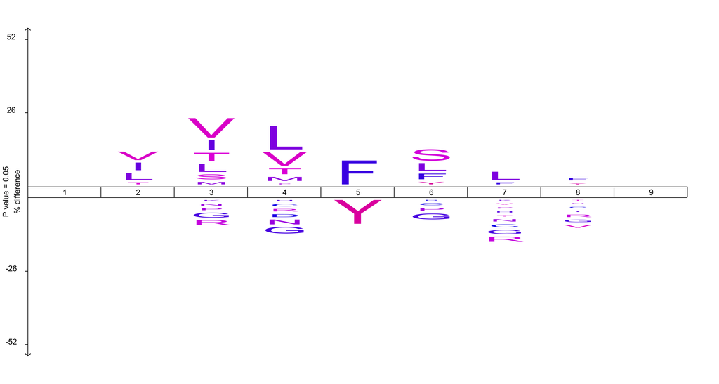

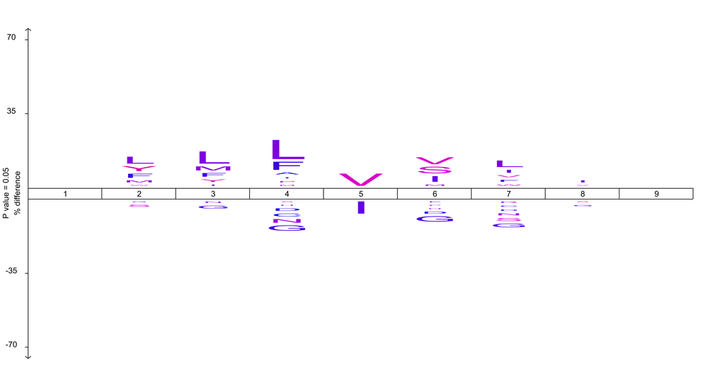

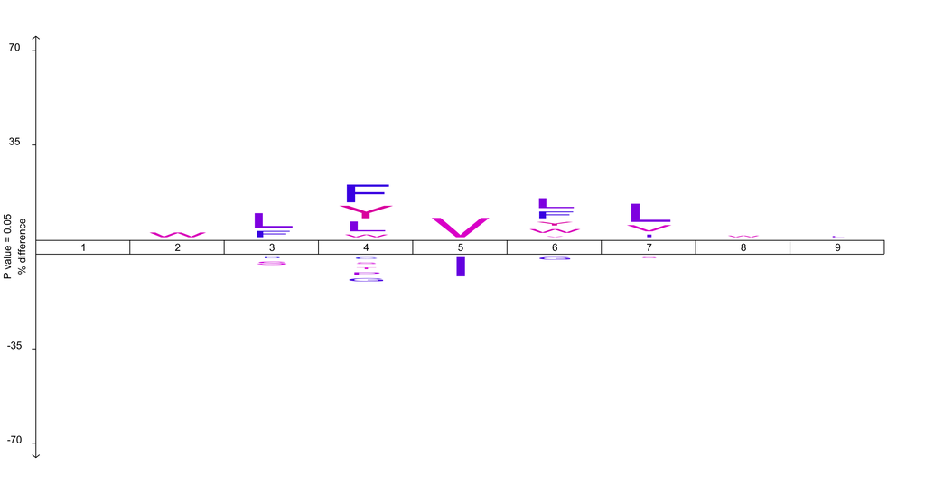